# Curso de Jurimetria

2016-08-08

## Outline

- Aplicações em jurimetria.
- Ferramental técnico + fundamentação teórica.
- Foco em *insights* para administração judiciária e políticas públicas.

## Hoje (08/08)

- Arrumação de dados: Câmaras criminais do TJSP
- Visualização de dados: Câmaras criminais do TJSP
- Análise de sobrevivência e mineração de movimentações processuais: Recuperações judiciais
- Web scraping: Câmaras criminais do TJSP

## Amanhã (09/08)

- Estatística forense: paternidade
- Teoria da decisão no direito: perda de uma chance e valor de indenização
- Randomização vs Intencionalidade na justiça
- Alocação de varas, complexidade processual, produtividade e especialização

## Quarta (10/08)

- Processos estocásticos e simulação: Cadastro Nacional de Adoção
- Classificação de danos morais e guidelines para decisões
- Jurimetria e como fazer boas leis
- Discussões e feedback

## Jurimetria

## Jurimetria

- Estatística aplicada ao direito.
- Três pilares: jurídico, estatístico e computacional.
- A jurimetria estuda o Direito no plano concreto.

## Prática em jurimetria

- Bases de dados criadas para fins gerenciais.
- Dados faltantes, documentação ruim, problemas de acesso.
- Necessário dominar ferramentas de extração e transformação de dados.

## Ferramental de trabalho da ABJ

- Software estatístico R.
- `tidyverse`:
  - `lubridate` para datas.
  - `stringr` para textos.
  - `dplyr` e `tidyr` para `data_frames`.
  - `ggplot2` para gráficos.
  - `httr`, `xml2` e `rvest` para web scraping

## Motivação 1

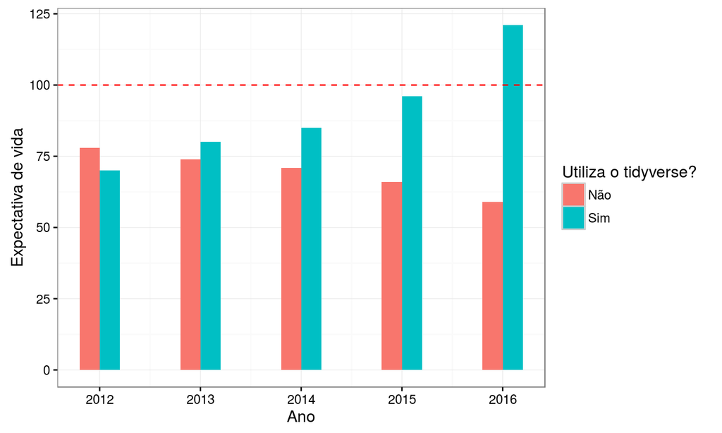

## Motivação 2

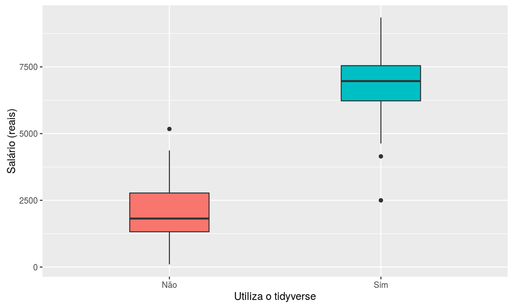

## Motivação 3

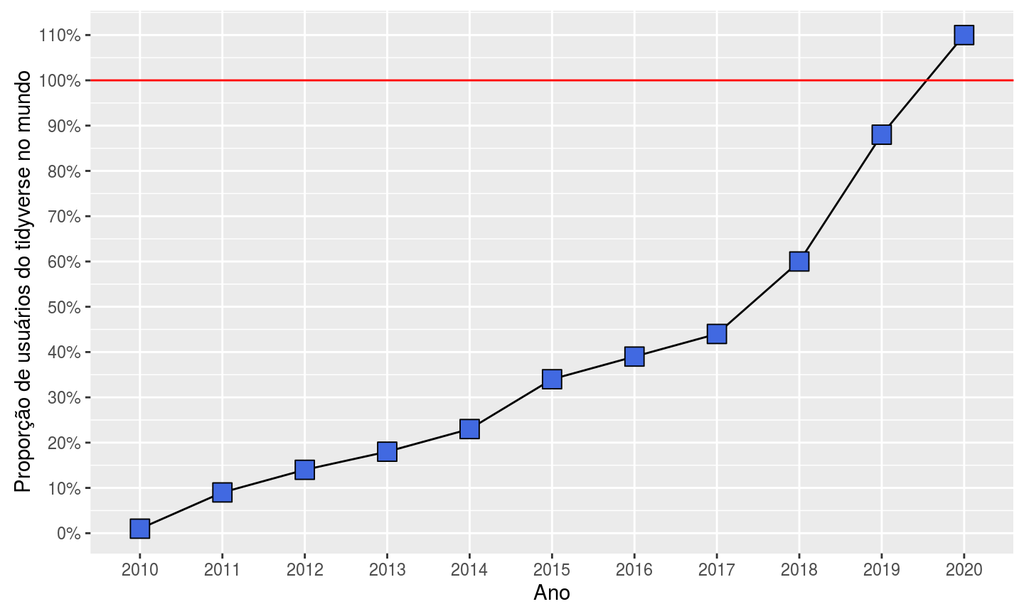

## Arrumação de dados

[figure not shown]

## Data tidying

Uma base de dados é considerada "tidy" se

- Cada observação é uma linha do bd.
- Cada variável é uma coluna do bd.
- Para cada unidade observacional temos um `data_frame` separado (possivelmente com chaves de associação).

## Pipe `%>%`

```r
x <- c(1, 2, 3, 4)
x %>% sum %>% sqrt
```

```
## [1] 3.162278
```

## Receita de bolo

```r
esfrie(asse(coloque(bata(acrescente(recipiente(
  rep("farinha", 2), "água", "fermento", "leite", "óleo"),
  "farinha", até = "macio"), duração = "3min"), lugar = "forma",
  tipo = "grande", untada = T), duração = "50min"),
  "geladeira", "20min")
```

## Receita de bolo

```r
recipiente(rep("farinha", 2), "água", "fermento", "leite", "óleo") %>%
  acrescente("farinha", até = "macio") %>%
  bata(duração = "3min") %>%
  coloque(lugar = "forma", tipo = "grande", untada = T) %>%
  asse(duração = "50min") %>%
  esfrie("geladeira", "20min")
```

## `lubridate`

- `ymd` e derivados para ler datas.
- `year`, `month` etc para extrair informações de datas.
- `years`, `months` etc para criar vetores de datas.
- `floor_date` para categorizar uma data.

## `stringr`

- Organiza as principais funções de manipulação de texto do R.
- O primeiro argumento da função é sempre uma `string`.
- As funções sempre começam com `str_`.

## Regex

[output not shown]

## `dplyr` e `tidyr`

Cinco verbos que resolvem 90% dos problemas.

- `filter`
- `mutate`
- `arrange`
- `select`
- `summarise`
- `gather` e `spread`

## Visualização

## `ggplot2`

O que é um gráfico estatístico?

> "… that a statistical graphic is a mapping from data to aesthetic attributes (colour, shape, size) of geometric objects (points, lines, bars). The plot may also contain statistical transformations of the data and is drawn on a specific coordinate system."

Essa é a ideia de Leland Wilkinson, proposta em **The Grammar of Graphics**.

## Motivação

- É fácil de usar, e uma vez que você aprende, consegue fazer qualquer gráfico.
- Faz parte do universo `tidyverse`.
- Gráficos bonitos e elegantes.

## Estrutura

- Dados — `data =`
- Aspectos estéticos (*mapping*) — `aes()`
- Formas geométricas — `geom_()`
- Transformações estatísticas — `stat =`

## Exemplos

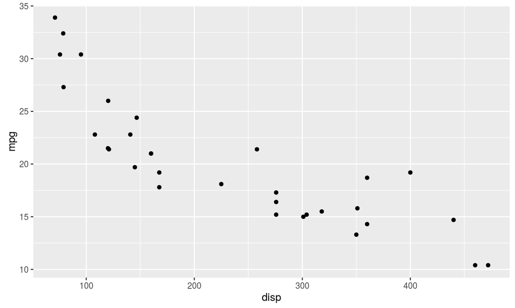

```r
ggplot(data = mtcars, aes(x = disp, y = mpg)) +
  geom_point()
```

## Exemplos

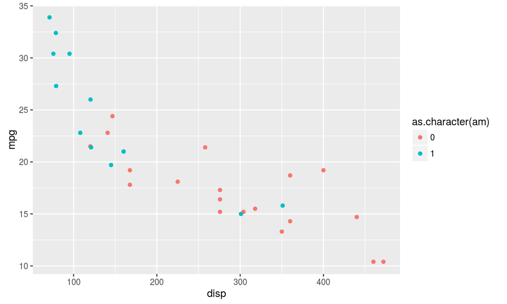

```r
ggplot(data = mtcars) +
  geom_point(aes(x = disp, y = mpg, colour = as.character(am)))
```

## Exemplos

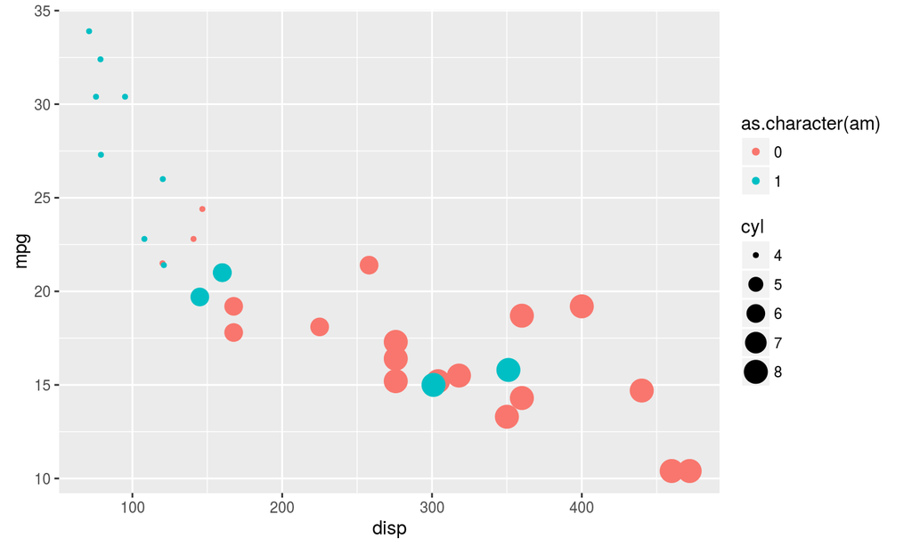

```r
ggplot(data = mtcars) +
  geom_point(aes(x = disp, y = mpg, colour = as.character(am),
                                size = cyl))
```

## Exemplos

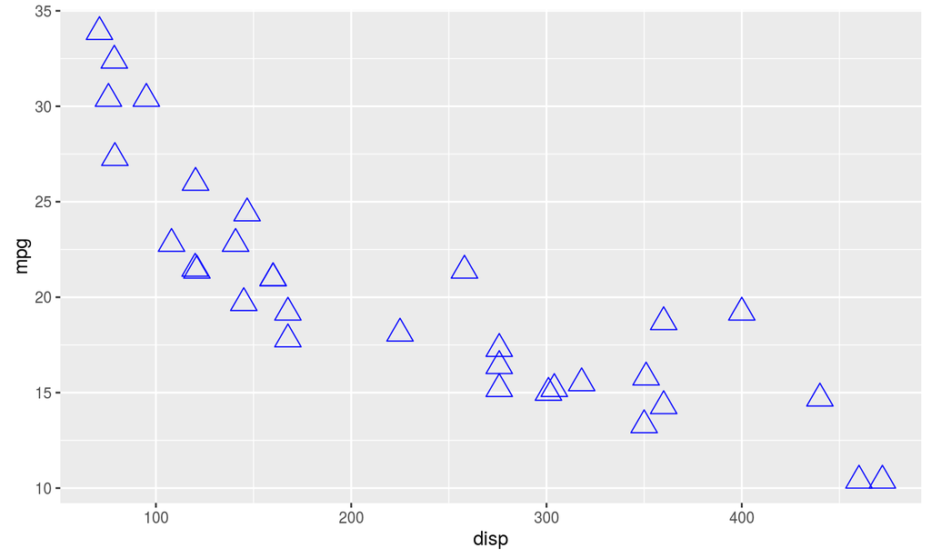

```r
ggplot(data = mtcars) +
  geom_point(aes(x = disp, y = mpg), colour = "blue", size = 5,
             shape = 2)
```

## Exemplo câmaras

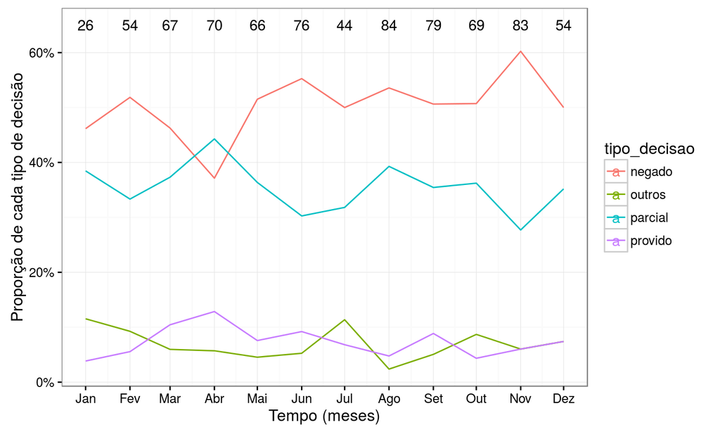

## Exemplo câmaras

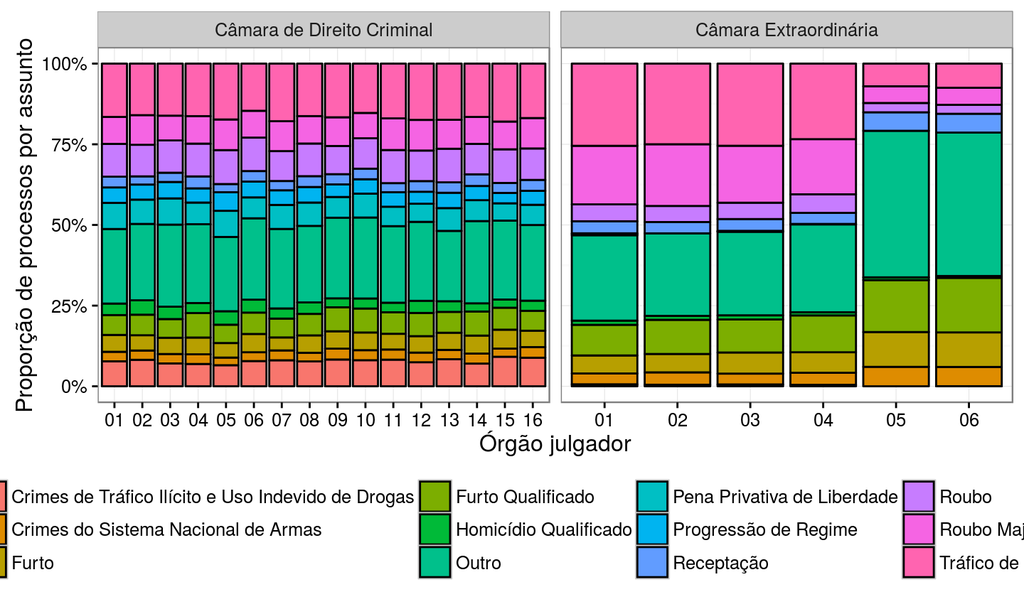

## Exemplo câmaras

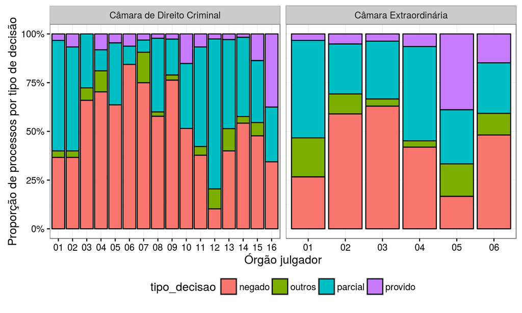